# Exploratory data Analysis of Diabetes Dataset

#### By: Sue, May 2018

```r
setwd("C:/USF/614/ML Project")
Data <- read.csv("diabetic_data.csv", na.string = "?", header = T)
str(Data)
```

```
## 'data.frame':    101766 obs. of  50 variables:
##  $ encounter_id            : int  2278392 149190 64410 500364 16680 35754 55842 63768 12522 15738 ...
##  $ patient_nbr             : int  8222157 55629189 86047875 82442376 42519267 82637451 84259809 114882984 48330783 63555939 ...
##  $ race                    : Factor w/ 5 levels "AfricanAmerican",..: 3 3 1 3 3 3 3 3 3 3 ...
##  $ gender                  : Factor w/ 3 levels "Female","Male",..: 1 1 1 2 2 2 2 2 1 1 ...
##  $ age                     : Factor w/ 10 levels "[0-10)","[10-20)",..: 1 2 3 4 5 6 7 8 9 10 ...
##  $ weight                  : Factor w/ 9 levels "[0-25)","[100-125)",..: NA NA NA NA NA NA NA NA NA NA ...
##  $ admission_type_id       : int  6 1 1 1 1 2 3 1 2 3 ...
##  $ discharge_disposition_id: int  25 1 1 1 1 1 1 1 1 3 ...
##  $ admission_source_id     : int  1 7 7 7 7 2 2 7 4 4 ...
##  $ time_in_hospital        : int  1 3 2 2 1 3 4 5 13 12 ...
##  $ payer_code              : Factor w/ 17 levels "BC","CH","CM",..: NA NA NA NA NA NA NA NA NA NA ...
##  $ medical_specialty       : Factor w/ 72 levels "AllergyandImmunology",..: 38 NA NA NA NA NA NA NA NA 19 ...
##  $ num_lab_procedures      : int  41 59 11 44 51 31 70 73 68 33 ...
##  $ num_procedures          : int  0 0 5 1 0 6 1 0 2 3 ...
```

[output cut: 36 more lines]

It sounds like some columns have many missing values. We take a closer look at them.

```r
library(DataExplorer)
```

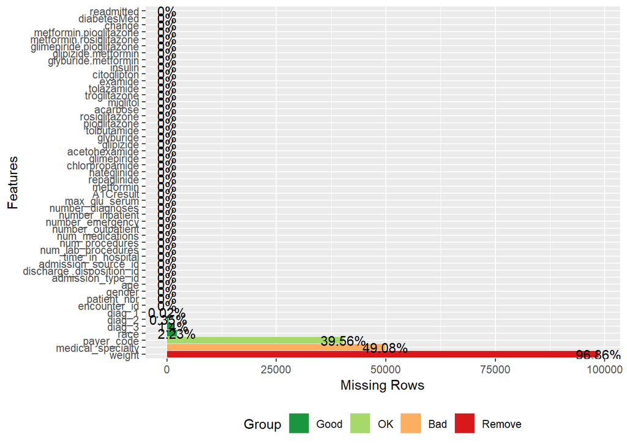

```r
plot_missing(Data)
```

As it can be seen the following columns have lots of NAs: Weight Medical_specialty Payer_code Therefore I delet these columns. Also encounter_id and patient_nbr are not needed for the analysis, therefore I delete them as well. Other than the tree columns that are shown there are two columns of Max_glucose and A1c that contain many “None” or basicly NA values. I am not going to delete them. Because of 2 reasons:

1. These variables can be good predictors of length of stay.
2. Even having None for these values can be an indicator of something! As you will see in the future analysis only patients with certain admission or discharge types have this data.

```r
Data <- Data[, -c(1, 2, 6,11,12)]
Data <- na.omit(Data)
```

```r
table(Data$A1Cresult)
```

```
##
##    >7    >8  None  Norm
##  3708  7631 81860  4854
```

```r
table(Data$max_glu_serum)
```

```
##
##  >200  >300  None  Norm
##  1449  1227 92845  2532
```

```r
table(Data$A1Cresult, Data$max_glu_serum)
```

```
##
##         >200  >300  None  Norm
##   >7      18    15  3645    30
##   >8      35   108  7460    28
##   None  1380  1103 76941  2436
##   Norm    16     1  4799    38
```

As we can see there are two classes of variables in this dataset: integer and factors. While most of these columns have right data types folowing columns should be either characters or factors, but they are considered to be integers. We should fix this problem.

```r
Data$discharge_disposition_id <- as.factor(Data$discharge_disposition_id)
Data$admission_type_id <- as.factor(Data$admission_type_id)
Data$admission_source_id <- as.factor(Data$admission_source_id)
```

## Spliting Data into Training and Test Sets

Before going any further I want to split the data into training and test sets to prevent leakage of information.

```r
library(lattice)
library(caret)
set.seed(1234)
trainIndex <- createDataPartition(Data$readmitted, p=0.80, list=FALSE,times=1)
train_Data <- Data[trainIndex,]
test_Data <- Data[-trainIndex,]
```

# Some graphs to Explore Training Data

We can take a closer look:

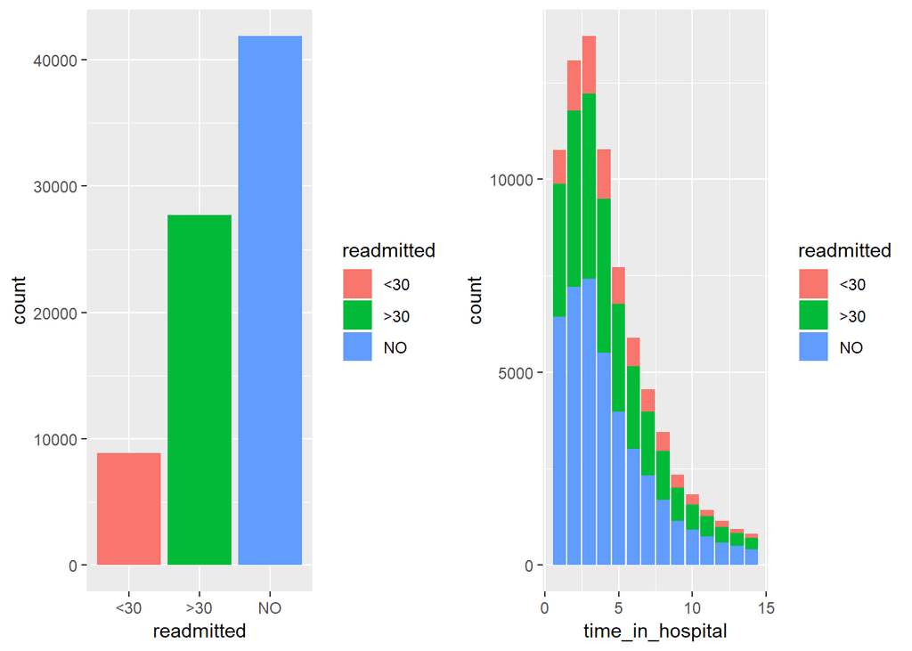

```r
library(ggplot2)
library(gridExtra)
a <- ggplot(data = train_Data) +
  geom_bar(aes(x=readmitted, fill=readmitted))

b <- ggplot(data = train_Data) +
  geom_bar(aes(x=time_in_hospital, fill=readmitted))

grid.arrange(a, b, ncol=2)
```

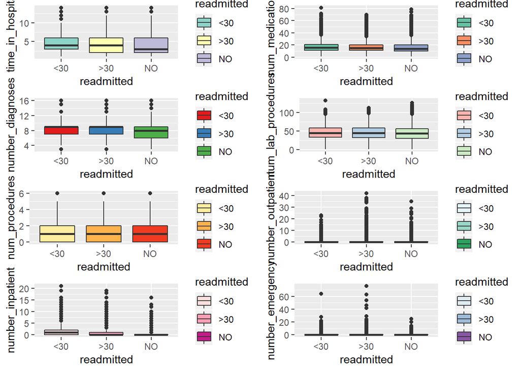

```r
library(ggplot2)
library(gridExtra)
a <- ggplot(data = train_Data) +
  geom_boxplot(aes(x=readmitted, y=time_in_hospital, fill=readmitted)) +
   scale_fill_brewer(palette="Set3")

b <- ggplot(data = train_Data) +
  geom_boxplot(aes(x=readmitted, y=num_medications, fill=readmitted)) +
  scale_fill_brewer(palette="Set2")

c <- ggplot(data = train_Data) +
  geom_boxplot(aes(x=readmitted, y=number_diagnoses, fill=readmitted)) +
  scale_fill_brewer(palette="Set1")

d <- ggplot(data = train_Data) +
  geom_boxplot(aes(x=readmitted, y=num_lab_procedures, fill=readmitted)) +
  scale_fill_brewer(palette="Pastel1")

e <- ggplot(data = train_Data) +
  geom_boxplot(aes(x=readmitted, y=num_procedures, fill=readmitted)) +
  scale_fill_brewer(palette="YlOrRd")

f <- ggplot(data = train_Data) +
  geom_boxplot(aes(x=readmitted, y=number_outpatient, fill=readmitted)) +
  scale_fill_brewer(palette="BuGn")

g <- ggplot(data = train_Data) +
  geom_boxplot(aes(x=readmitted, y=number_inpatient, fill=readmitted)) +
  scale_fill_brewer(palette="RdPu")

h <- ggplot(data = train_Data) +
  geom_boxplot(aes(x=readmitted, y=number_emergency, fill=readmitted)) +
  scale_fill_brewer(palette="BuPu")

grid.arrange(a, b, c, d, e,f, g, h, nrow=4, ncol=2)
```

Lots of outliers in number of medications. These variables are not significantly different for different cases of readmision. Time in hospital and number of medication tends to be higher for people who got reaqdmitted in ess than 30 days.

Specifically some relationships can be very interesting. Like:

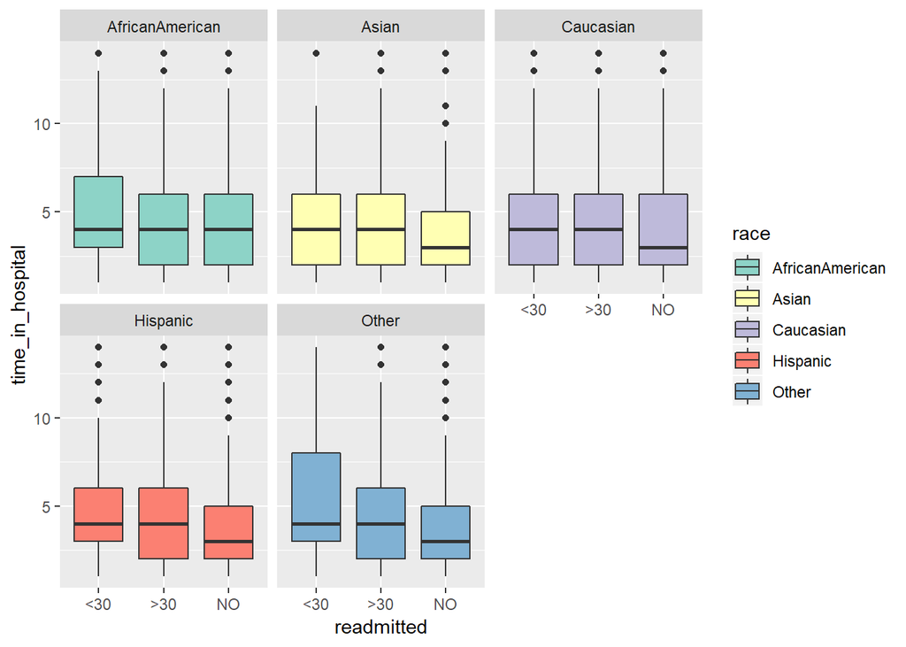

```r
ggplot(data = train_Data,aes(x=readmitted, y=time_in_hospital, fill=race)) +
  geom_boxplot() +
   scale_fill_brewer(palette="Set3")+
  facet_wrap(~ race)
```

As you can see they are almost in the same range. Therefore we cannot say that readmission type, time in hospital and race has any interaction with each other! For more accurate estimate we can do ANOVA test, but as this is not a very important factor in my analysis and also the plot does not show significant differences I am not going to do ANOVA analysis!

Now I want to investigate the effects of A1C and Max_Glocose on length of stay and admission type.

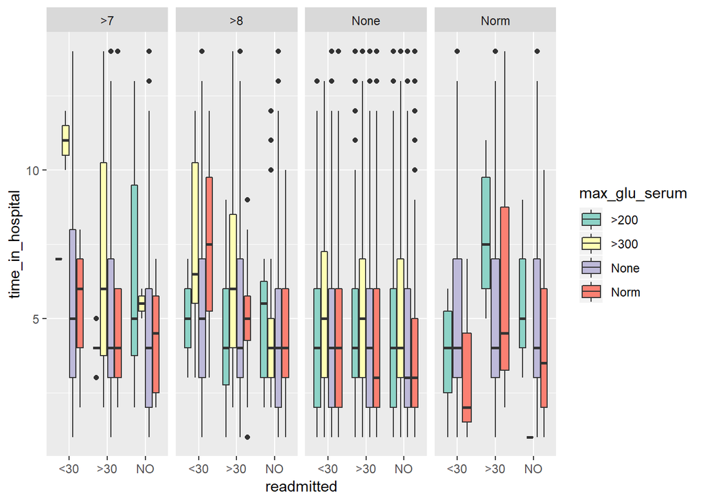

```r
ggplot(data = train_Data,aes(x=readmitted, y=time_in_hospital, fill=max_glu_serum )) +
  geom_boxplot() +
   scale_fill_brewer(palette="Set3")+
  facet_wrap(~ A1Cresult , ncol=4)
```

Here we can see the interaction between A1C, max glucose level, type of readmission and time in hospial in just one graph.“None” shows missing values.One thing that this graph shows is that people with A1C>8 and 7 and high max glocose level tend to have higher length of saty in hospital and higher odds of <30 readmission.

## ANOVA Test for Investigating Interaction Between Readmission Status, A1C and Max Glucose Level

```r
cort <- aov(time_in_hospital ~ A1Cresult*readmitted, data = Data)
summary(cort)
```

```
##                         Df Sum Sq Mean Sq F value  Pr(>F)
## A1Cresult                3   4172  1390.5 156.488 < 2e-16 ***
## readmitted               2   2864  1431.8 161.130 < 2e-16 ***
## A1Cresult:readmitted     6    190    31.7   3.573 0.00153 **
## Residuals            98041 871173     8.9
## ---
## Signif. codes:  0 '***' 0.001 '**' 0.01 '*' 0.05 '.' 0.1 ' ' 1
```

```r
cort <- aov(time_in_hospital ~ max_glu_serum*readmitted, data = Data)
summary(cort)
```

```
##                             Df Sum Sq Mean Sq F value Pr(>F)
## max_glu_serum                3   1936   645.5  72.428 <2e-16 ***
## readmitted                   2   2633  1316.6 147.736 <2e-16 ***
## max_glu_serum:readmitted     6    108    18.0   2.018 0.0597 .
## Residuals                98041 873721     8.9
## ---
## Signif. codes:  0 '***' 0.001 '**' 0.01 '*' 0.05 '.' 0.1 ' ' 1
```

ANOVA test shows that there is an interaction between A1C and readmission status but not between max glocose and readmission. I am going to explore it more in predictive analysis section.

## Histograms and Relationship between Numeric variables:

Now I want to explore the relationship between numeric features and also their histogram for different readmission statuses:

```r
library(GGally)
```

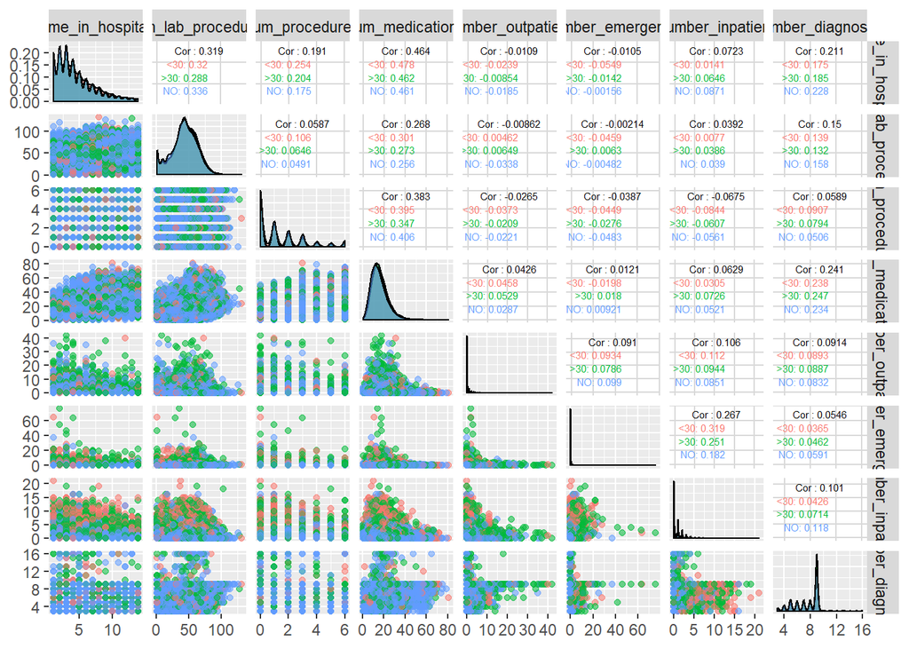

```r
library(ggplot2)
ggpairs(Data, columns = c(7:13, 17), aes(colour = readmitted, alpha = 0.4), upper = list(continuous = wrap("cor", size = 2)))
```

This is a great graph. Shows us:

1. The relationship between different features.
2. The histogram for each feature.
3. The correlation coefficients

This figure can give us an idea about outliers. Also distribution of each feature and if there is any strange thing about the data. Like having negative value for features that have to be positive like length of stay in hospital. As you can see there is nothing strange about these features other than some outliers.

Now I want to focus more on correlation coefficients:

## Investigating Linear Correlation Between Quantitative Variables

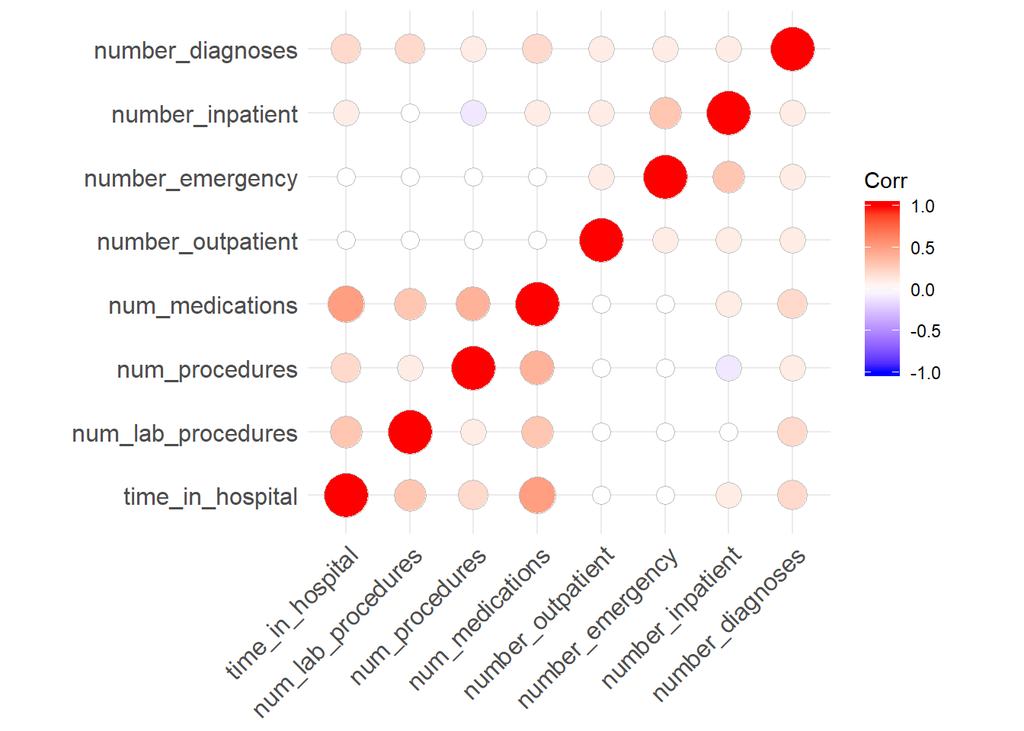

```r
library(ggcorrplot)
corr <- round(cor(Data[,c(7:13, 17)]), 1)
theme_set(theme_gray(base_size = 10))
ggcorrplot(corr, method = 'circle')
```

As we can see these numeric variables are not very much correlated (at least no linear correlation according to “Pearsone” method!). To find the exact number for correlation and the p-value I use Hmisc package as I cannot get p-values by cor function:

```r
library(survival)
library(Hmisc)
cor <- rcorr(as.matrix(Data[,c(7:13, 17)]), type="pearson")
cor$r
```

```
##                    time_in_hospital num_lab_procedures num_procedures
## time_in_hospital         1.00000000         0.31864662     0.19113294
## num_lab_procedures       0.31864662         1.00000000     0.05866545
## num_procedures           0.19113294         0.05866545     1.00000000
## num_medications          0.46419938         0.26784283     0.38295832
## number_outpatient       -0.01090978        -0.00861874    -0.02645870
## number_emergency        -0.01050555        -0.00213756    -0.03872652
## number_inpatient         0.07228750         0.03920697    -0.06754491
## number_diagnoses         0.21124201         0.15028933     0.05892887
##                    num_medications number_outpatient number_emergency
## time_in_hospital        0.46419938       -0.01090978      -0.01050555
## num_lab_procedures      0.26784283       -0.00861874      -0.00213756
## num_procedures          0.38295832       -0.02645870      -0.03872652
## num_medications         1.00000000        0.04264992       0.01212530
## number_outpatient       0.04264992        1.00000000       0.09103383
## number_emergency        0.01212530        0.09103383       1.00000000
## number_inpatient        0.06290078        0.10598011       0.26717485
## number_diagnoses        0.24148128        0.09141796       0.05461959
##                    number_inpatient number_diagnoses
## time_in_hospital         0.07228750       0.21124201
## num_lab_procedures       0.03920697       0.15028933
## num_procedures          -0.06754491       0.05892887
## num_medications          0.06290078       0.24148128
## number_outpatient        0.10598011       0.09141796
## number_emergency         0.26717485       0.05461959
## number_inpatient         1.00000000       0.10125183
## number_diagnoses         0.10125183       1.00000000
```

```r
cor$P
```

```
##                    time_in_hospital num_lab_procedures num_procedures
## time_in_hospital                 NA        0.000000000              0
## num_lab_procedures     0.0000000000                 NA              0
## num_procedures         0.0000000000        0.000000000             NA
## num_medications        0.0000000000        0.000000000              0
## number_outpatient      0.0006348241        0.006958215              0
## number_emergency       0.0010029622        0.503281692              0
## number_inpatient       0.0000000000        0.000000000              0
## number_diagnoses       0.0000000000        0.000000000              0
##                    num_medications number_outpatient number_emergency
## time_in_hospital      0.0000000000      0.0006348241     0.0010029622
## num_lab_procedures    0.0000000000      0.0069582153     0.5032816919
## num_procedures        0.0000000000      0.0000000000     0.0000000000
## num_medications                 NA      0.0000000000     0.0001464947
## number_outpatient     0.0000000000                NA     0.0000000000
## number_emergency      0.0001464947      0.0000000000               NA
## number_inpatient      0.0000000000      0.0000000000     0.0000000000
## number_diagnoses      0.0000000000      0.0000000000     0.0000000000
##                    number_inpatient number_diagnoses
## time_in_hospital                  0                0
## num_lab_procedures                0                0
## num_procedures                    0                0
## num_medications                   0                0
## number_outpatient                 0                0
## number_emergency                  0                0
## number_inpatient                 NA                0
## number_diagnoses                  0               NA
```

Here you see Pearson correlation coefficients and their p-valuse. Non of these values are high and that shows no “Linear” correlation between these variables!

## Readmission status and Categorical Variables

Is there any relatinship between readmission status and categorical variables? For this purpose I use “GGaly” package to plot a pair graph of these categorical variables:

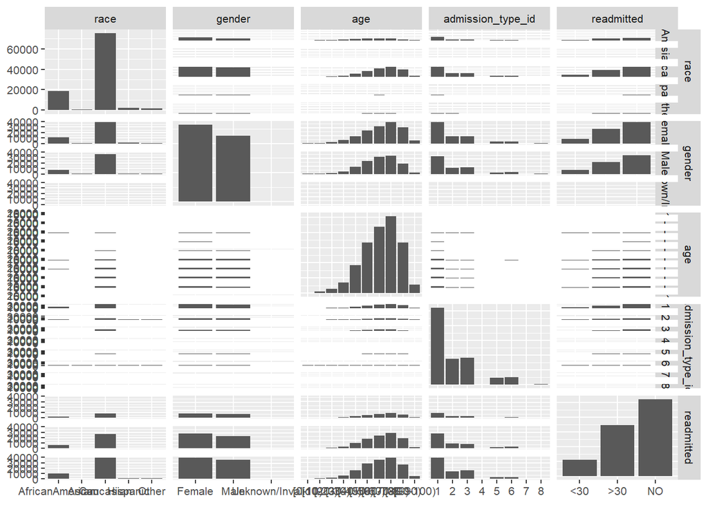

```r
library(GGally)
cat_Data <- Data[,c(1:4, 45)]
ggpairs(cat_Data)
```

Also this figure shows that gender has two levels and the unknown level is almost empty (one observation)! This is also the case with race and admission id. Some levels are almost empty.

## Standardizing the Data

Some models like instance-based models for clustering and SVM work better with standardized data.Therefore I standardize data with “caret” package. To insure no leakage of information between train and test datasets, I apply the model I obtained through “preProcess of train” dataset on train and test datasets separately.

```r
library(caret)
prep_train_Data <- preProcess(train_Data, method=c("center", "scale"))
train_Data <- predict(prep_train_Data, train_Data)
test_Data <- predict(prep_train_Data, test_Data)
```

There are 8 truly integer variables in the dataset that I want to play with and discover if there is any relationship between them if I can get good clusters by clustering or if I can get goor principle components (PCs) for future analysis. I first make a dataset of just numeric variables.

```r
numeric_train_Data <- train_Data[,c(7:13, 17, 45)]
numeric_test_Data <- test_Data[,c(7:13, 17, 45)]
```

# Exploratory Data Analysis on Quantitative Features of Training Set

```r
summary(numeric_train_Data)
```

```
##  time_in_hospital  num_lab_procedures num_procedures    num_medications
##  Min.   :-1.1448   Min.   :-2.13848   Min.   :-0.7911   Min.   :-1.8615
##  1st Qu.:-0.8105   1st Qu.:-0.61646   1st Qu.:-0.7911   1st Qu.:-0.6315
##  Median :-0.1418   Median : 0.04308   Median :-0.2068   Median :-0.1394
##  Mean   : 0.0000   Mean   : 0.00000   Mean   : 0.0000   Mean   : 0.0000
##  3rd Qu.: 0.5269   3rd Qu.: 0.70263   3rd Qu.: 0.3775   3rd Qu.: 0.4756
##  Max.   : 3.2016   Max.   : 4.50768   Max.   : 2.7147   Max.   : 7.9789
##  number_outpatient number_emergency  number_inpatient  number_diagnoses
##  Min.   :-0.2937   Min.   :-0.2086   Min.   :-0.5075   Min.   :-2.4625
##  1st Qu.:-0.2937   1st Qu.:-0.2086   1st Qu.:-0.5075   1st Qu.:-0.8255
##  Median :-0.2937   Median :-0.2086   Median :-0.5075   Median : 0.2659
##  Mean   : 0.0000   Mean   : 0.0000   Mean   : 0.0000   Mean   : 0.0000
##  3rd Qu.:-0.2937   3rd Qu.:-0.2086   3rd Qu.: 0.2784   3rd Qu.: 0.8116
##  Max.   :32.9023   Max.   :77.8781   Max.   :15.9974   Max.   : 4.6313
##  readmitted
##  <30: 8853
##  >30:27720
##  NO :41871
##
##
##
```

All numeric parameters are centered and scaled.

# Unsupervised Learning

## Clustering

```r
# generating indices:
set.seed(123)
n <- round(0.01*nrow(numeric_train_Data))
sample_index <- sample(1:nrow(numeric_train_Data), n)

# Making a smaller dataset:
small_numeric_train_Data <- numeric_train_Data[sample_index,]
```

## Hierarchical Clustering:

I use the function hcut from factoextra package for this analysis. This package wants number of cut at the begining of the analysis, just for coloring the dendogram! As you will see later Silhouette method sugests k=4 for hierachical clustering. Therefore I will go ahead and choose k=4 for now. However this number is not going to affect the analysis. It is not like Kmean clustering!

Here I use Euclidean method for distance and “ward.D2” method of clustering which are the defauls.

```r
library(factoextra)
```

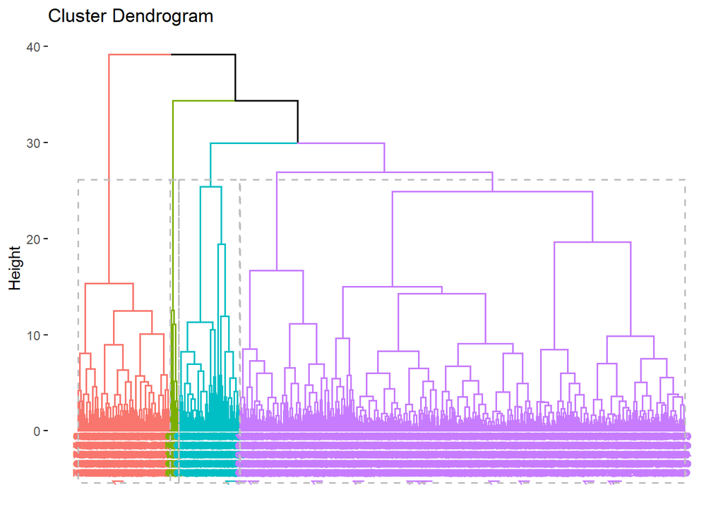

```r
res <- hcut(small_numeric_train_Data[,-9], k = 4, stand = TRUE)
fviz_dend(res, rect = TRUE)
```

##Visualizing the clusters we obtained from Hierarchical Method

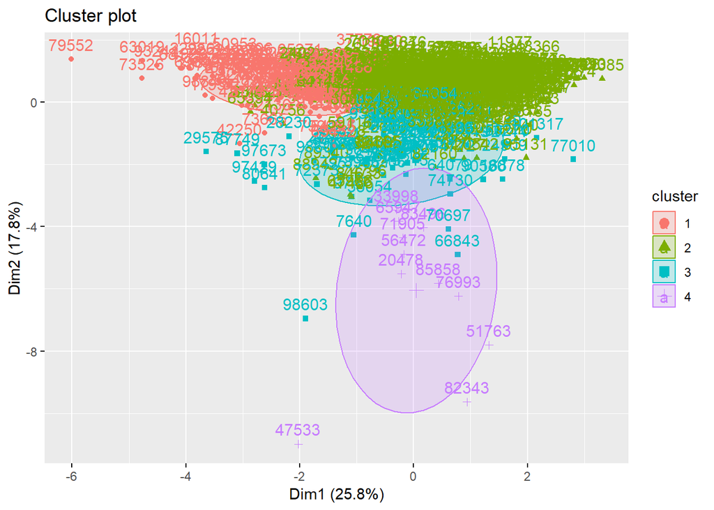

```r
fviz_cluster(res, frame.type = "norm", frame.level = 0.68)
```

# Cluster Validation for Hierarchical Method

## Elbow method

The total WSS measures the compactness of the clustering and we want it to be as small as possible.

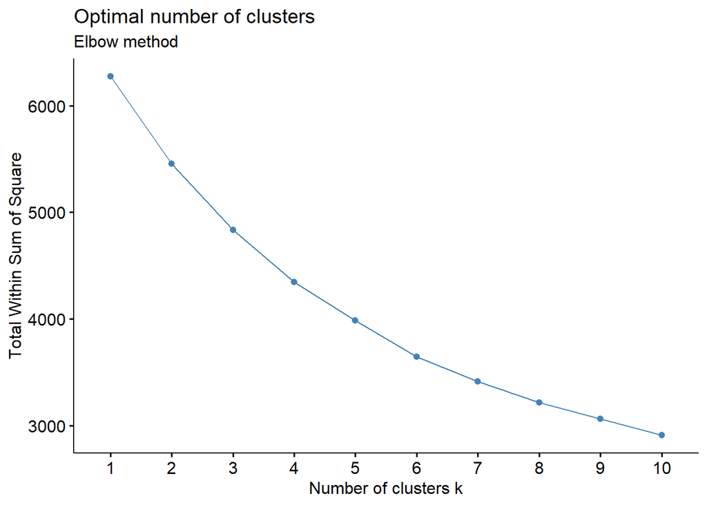

```r
library(NbClust)
fviz_nbclust(small_numeric_train_Data[,-9], hcut, method = c("wss"))+
  labs(subtitle = "Elbow method")
```

As number of clusters increases wss decreases. However this is not our only criteria for a good clustering. I am going to try other method of evaluations that are commenly used by other researchers.

## Average Silhouette Method

The average silhouette approach measures the quality of a clustering. That is, it determines how well each object lies within its cluster. A high average silhouette width indicates a good clustering.

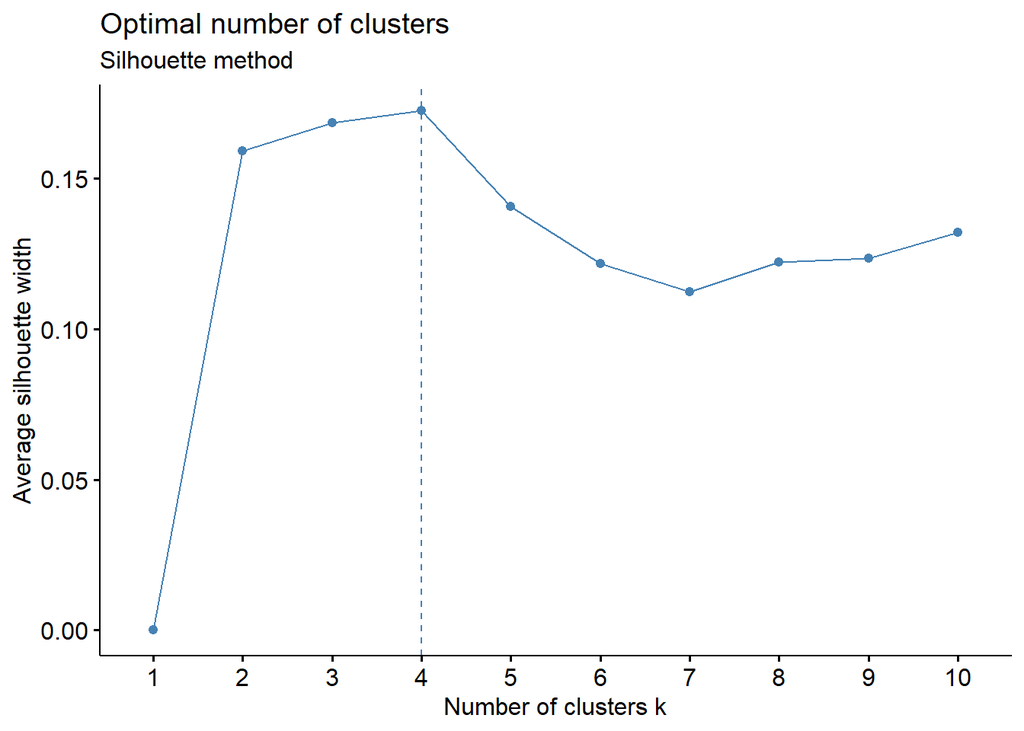

```r
library(NbClust)
fviz_nbclust(small_numeric_train_Data[,-9], hcut, method = c("silhouette"))+
labs(subtitle = "Silhouette method")
```

```
##   cluster size ave.sil.width
## 1       1  119          0.21
## 2       2  575          0.27
## 3       3   79         -0.05
## 4       4   11          0.29
```

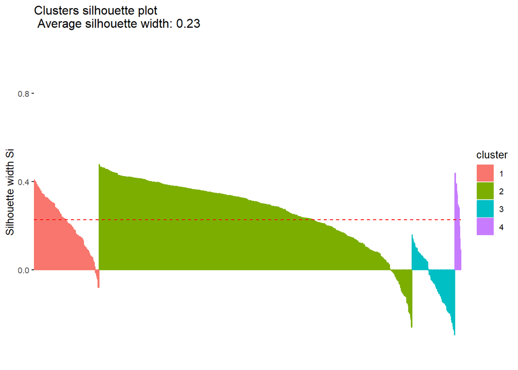

```r
fviz_silhouette(res)
```

The silhouette method measures how similar an object is to the other objects in its own cluster versus those in the neighbor cluster. Si values range from 1 to - 1: A value of Si close to 1 indicates that the object is well clustered. In the other words, the object is similar to the other objects in its group. A value of Si close to -1 indicates that the object is poorly clustered, and that assignment to some other cluster would probably improve the overall results. As we can see this method sugests that k=4 is the best, however there are still some observations that are misclustered! Now lets see what the other method of evaluation sugests.

## Gap Statistic Method

The gap statistic compares the total within intra-cluster variation for different values of k with their expected values under null reference distribution of the data. The estimate of the optimal clusters will be value that maximize the gap statistic (i.e, that yields the largest gap statistic). This means that the clustering structure is far away from the random uniform distribution of points.

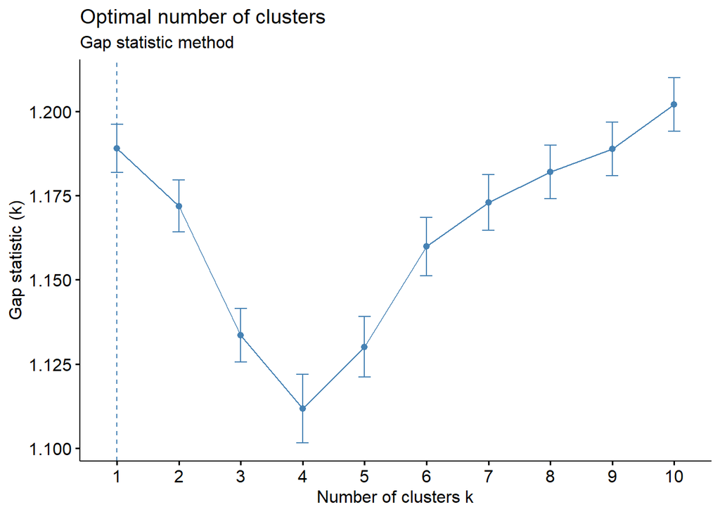

```r
library(NbClust)
set.seed(123)
fviz_nbclust(small_numeric_train_Data[,-9], hcut, method = c("gap_stat"))+
  labs(subtitle = "Gap statistic method")
```

To obtain an ideal clustering, we should select k such that we maximize the gap statistic. Here “Gap statistic method” is sugesting that k= 1 is the best. Therefore no clustering! Or I can say that the data does not have that much tendancy to cluster based on this method of evaluation! How think we can accept both findings of this method and Silhouette method base on how perfectionist we are!

## Kmeans Method

in which, each cluster is represented by the center or means of the data points belonging to the cluster. The K-means method is sensitive to anomalous data points and outliers.

The K-means method is sensitive to outliers. An alternative to k-means clustering is the K-medoids clustering or PAM (Partitioning Around Medoids, Kaufman & Rousseeuw, 1990), which is less sensitive to outliers compared to k-means.I have also use pam method it gives me almost the same result so I am not going to put it in this document!

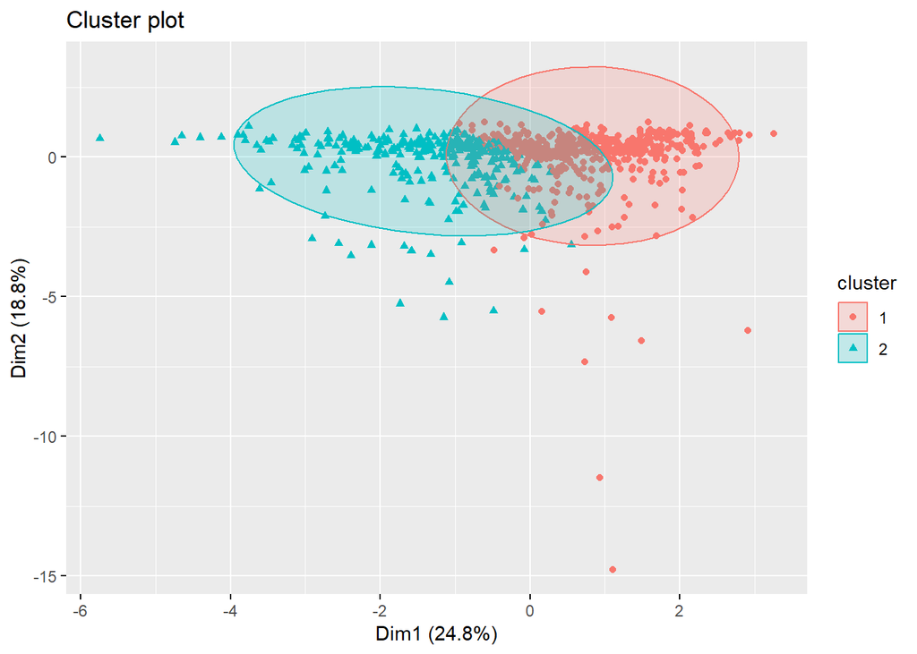

```r
library(cluster)
pam_clust <- pam(small_numeric_train_Data[,-9], 2)
fviz_cluster(pam_clust, stand = FALSE, geom = "point",
             frame.type = "norm")
```

# Cluster Validation

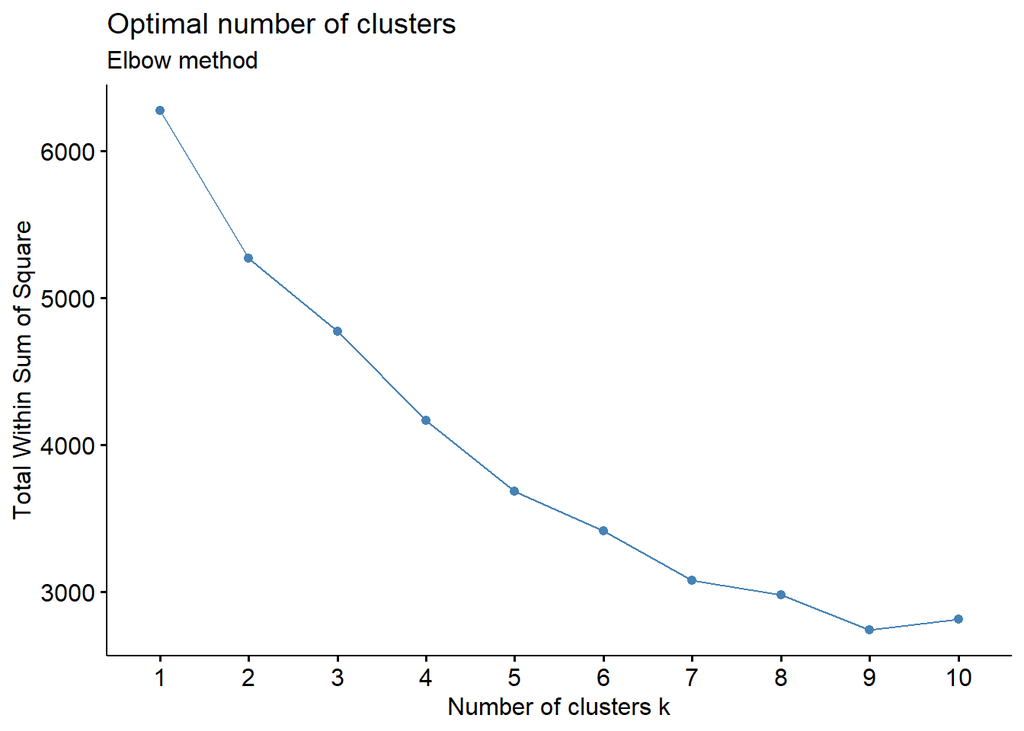

```r
library(cluster)
library(factoextra)
fviz_nbclust(small_numeric_train_Data[,-9],  kmeans, method = "wss") +
  labs(subtitle = "Elbow method")
```

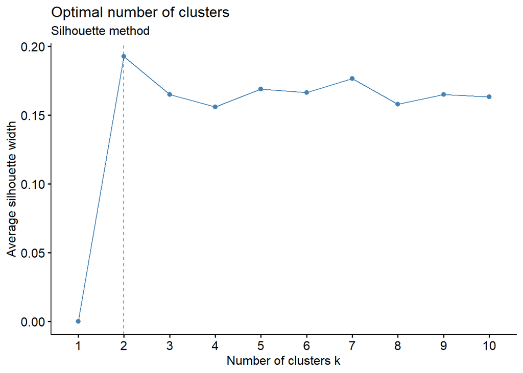

```r
# Silhouette method
fviz_nbclust(small_numeric_train_Data[,-9],  kmeans, method = "silhouette")+
  labs(subtitle = "Silhouette method")
```

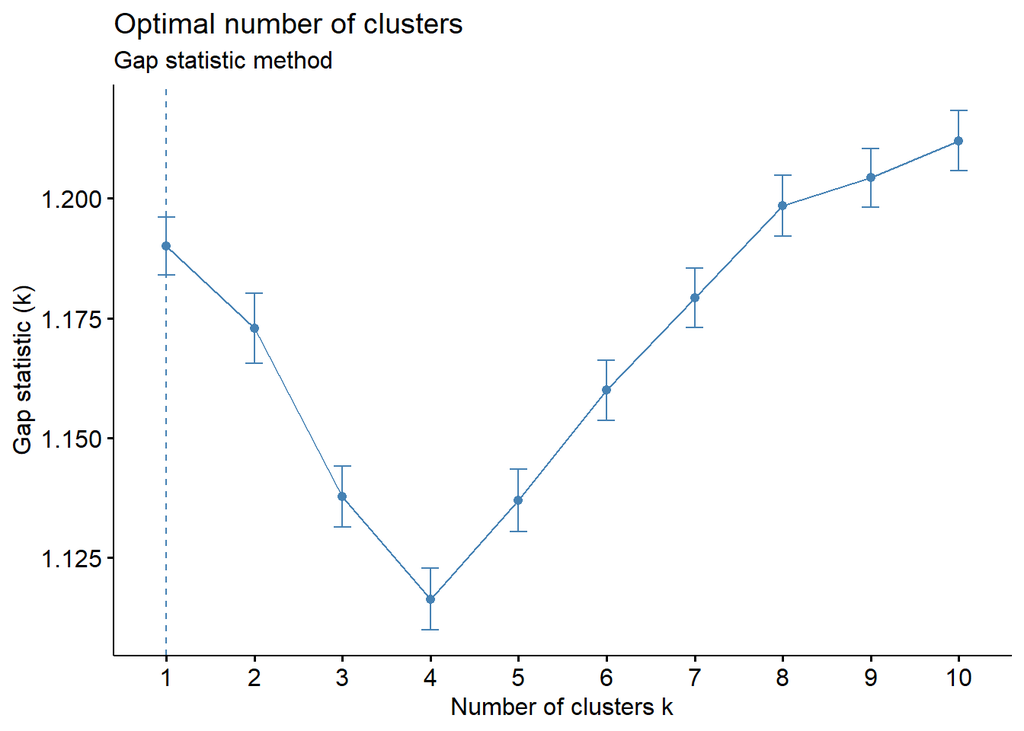

```r
# Gap statistic
set.seed(123)
fviz_nbclust(small_numeric_train_Data[,-9],  kmeans, nstart = 25,  method = "gap_stat", nboot = 50)+
  labs(subtitle = "Gap statistic method")
```

```
##   cluster size ave.sil.width
## 1       1  490          0.24
## 2       2  294          0.11
```

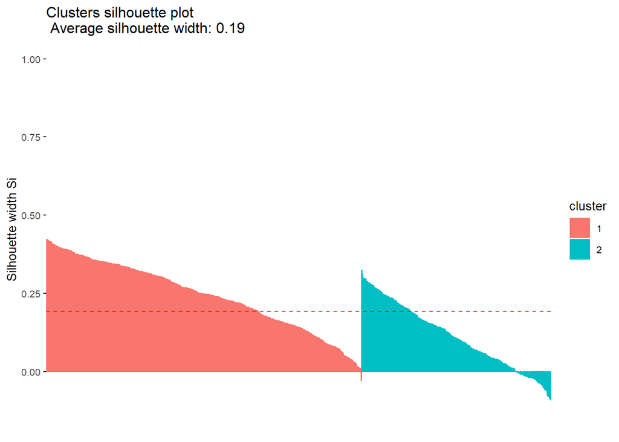

```r
fviz_silhouette(pam_clust)
```

The result we get are consistant with what we have obtained in previous section.

## PCA Analysis

Principal component analysis is used to extract the important information from a multivariate data table and to express this information as a set of few new variables called principal components. PCA method is particularly useful when the variables within the data set are highly correlated. Correlation indicates that there is redundancy in the data. Due to this redundancy, PCA can be used to reduce the original variables into a smaller number of new variables ( = principal components) explaining most of the variance in the original variables.

```r
# library("FactoMineR")
# res.pca <- PCA(small_numeric_train_Data[,-9], graph = FALSE)
# fviz_eig(res.pca, addlabels = TRUE, ylim = c(0, 50))
```

```r
set.seed(123)
pca_model <- prcomp(small_numeric_train_Data[,-9],
                 center = TRUE,
                 scale. = TRUE)
print(pca_model)
```

```
## Standard deviations (1, .., p=8):
## [1] 1.4363292 1.1920746 1.0059843 0.9897576 0.8921515 0.8069827 0.7994695
## [8] 0.6618044
##
## Rotation (n x k) = (8 x 8):
##                             PC1          PC2         PC3          PC4
## time_in_hospital   -0.531623337  0.047868135 -0.10787754  0.104943519
## num_lab_procedures -0.400919126  0.008474336 -0.49857035  0.037121290
## num_procedures     -0.347597944  0.246510756  0.65488160  0.061087113
## num_medications    -0.561616055  0.038822872  0.25576587 -0.000293572
## number_outpatient   0.008994240 -0.353493917  0.27144759 -0.789012279
## number_emergency   -0.002275919 -0.619538779  0.24618856  0.310383008
## number_inpatient   -0.115775682 -0.620940022 -0.03102123  0.307069248
## number_diagnoses   -0.326976259 -0.202507532 -0.33203770 -0.413167805
##                             PC5         PC6         PC7         PC8
## time_in_hospital   -0.202630804  0.29645505 -0.52002531 -0.54135330
## num_lab_procedures -0.496290709 -0.22164356  0.54003327  0.04664099
## num_procedures      0.156378705 -0.28834390  0.39412112 -0.35054046
## num_medications     0.002693498  0.10044347 -0.20270648  0.75264724
## number_outpatient  -0.396216457 -0.09803396 -0.08082556 -0.07487371
## number_emergency   -0.103182871  0.56711456  0.35477095 -0.03304614
## number_inpatient    0.137373931 -0.64595356 -0.26235008 -0.02864390
## number_diagnoses    0.708285926  0.14584873  0.20073266 -0.08880400
```

```r
get_eigenvalue(pca_model)
```

```
##       eigenvalue variance.percent cumulative.variance.percent
## Dim.1  2.0630415        25.788018                    25.78802
## Dim.2  1.4210419        17.763024                    43.55104
## Dim.3  1.0120045        12.650056                    56.20110
## Dim.4  0.9796201        12.245252                    68.44635
## Dim.5  0.7959344         9.949180                    78.39553
## Dim.6  0.6512211         8.140263                    86.53579
## Dim.7  0.6391515         7.989394                    94.52519
## Dim.8  0.4379850         5.474813                   100.00000
```

An eigenvalue > 1 indicates that PCs account for more variance than accounted by one of the original variables in standardized data. This is commonly used as a cutoff point for which PCs are retained. This holds true only when the data are standardized.

You can also limit the number of component to that number that accounts for a certain fraction of the total variance. For example, if you are satisfied with 70% of the total variance explained then use the number of components to achieve that.

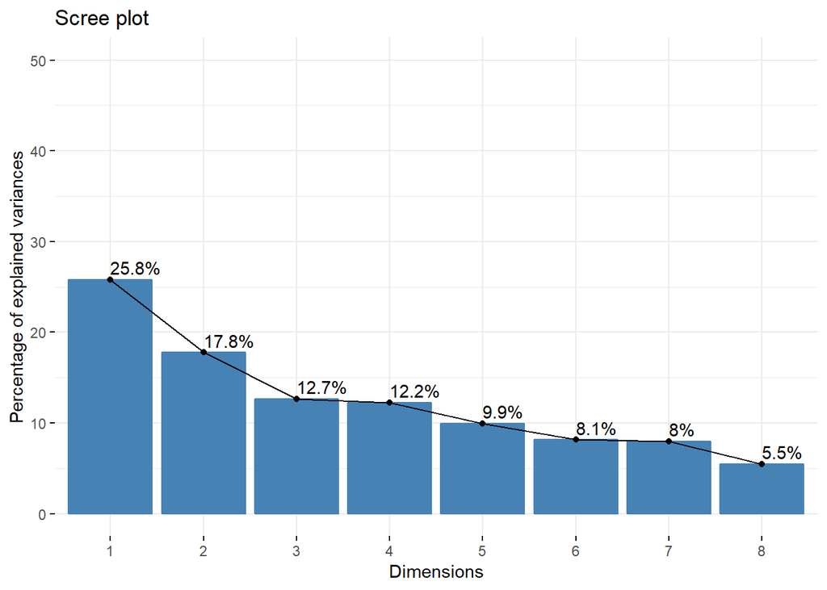

```r
library("FactoMineR")
fviz_eig(pca_model, addlabels = TRUE, ylim = c(0, 50))
```

## Correlation Circle

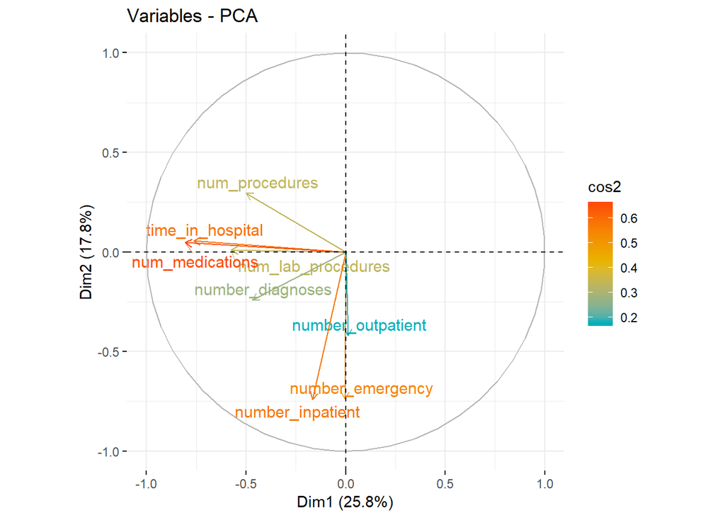

```r
fviz_pca_var(pca_model, col.var = "cos2",
             gradient.cols = c("#00AFBB", "#E7B800", "#FC4E07"),
             repel = TRUE # Avoid text overlapping
             )
```

The plot above is also known as variable correlation plots. It shows the relationships between all variables. It can be interpreted as follow:

- Positively correlated variables are grouped together.
- Negatively correlated variables are positioned on opposite sides of the plot origin (opposed quadrants).
- The distance between variables and the origin measures the quality of the variables on the factor map. Variables that are away from the origin are well represented on the factor map.

The quality of representation of the variables on factor map is called cos2 (square cosine, squared coordinates).

## Contributions of variables to PCs: For feature Selection in Predictive Analysis

The contributions of variables in accounting for the variability in a given principal component are expressed in percentage. Variables that are correlated with PC1 (i.e., Dim.1) and PC2 (i.e., Dim.2) are the most important in explaining the variability in the data set. Variables that do not correlated with any PC or correlated with the last dimensions are variables with low contribution and might be removed to simplify the overall analysis.

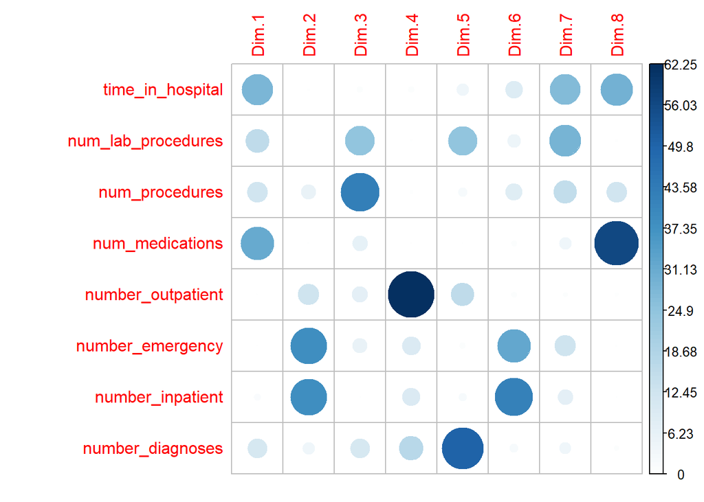

```r
library("corrplot")
var <- get_pca_var(pca_model)
corrplot(var$contrib, is.corr=FALSE)
```

As we will see in the predictive analysis later this result is consistant with what we found in Random Forest analysis. Most important factors here are:

- Number of medications
- Time in hospital
- Number of diagnosis
- Number of lab procedures

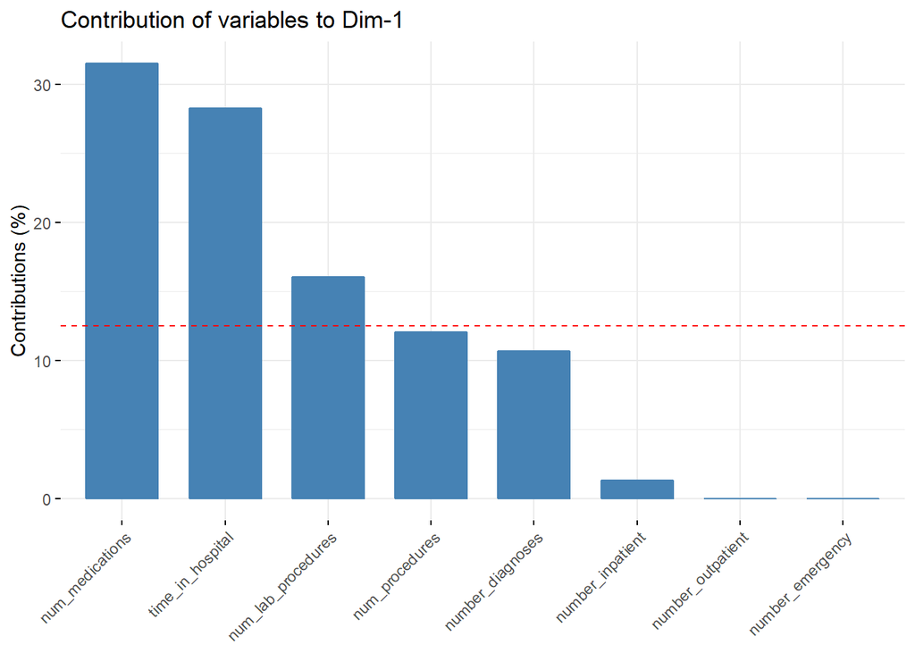

```r
# Contributions of variables to PC1
fviz_contrib(pca_model, choice = "var", axes = 1, top = 10)
```

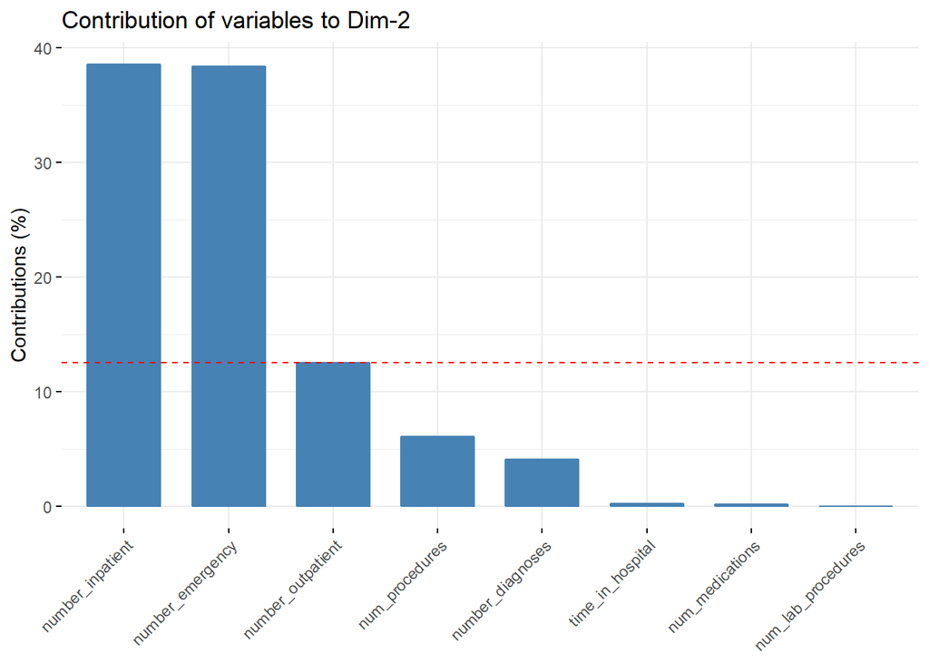

```r
# Contributions of variables to PC2
fviz_contrib(pca_model, choice = "var", axes = 2, top = 10)
```

As we will see later in predictive analysis these results are consistant with Random Forest ranking of important features. Here the following variables are contributing the most to the first PC:

1. Number of medications
2. Length of stay in hospital
3. Number of lab procedures

## Multiple Correspondence Analysis (MCA) on Categorical Features

The Multiple correspondence analysis (MCA) is method for summarizing and visualizing a data table containing more than two categorical variables. It can also be seen as a generalization of principal component analysis when the variables to be analyzed are categorical instead of quantitative.There are many categorical variables in this dataset. As we will see later including all of them in the predictive analysis is not helping the prediction power of the model. Here I want to see if I can extract some useful information from these categorical data through MCA analysis.

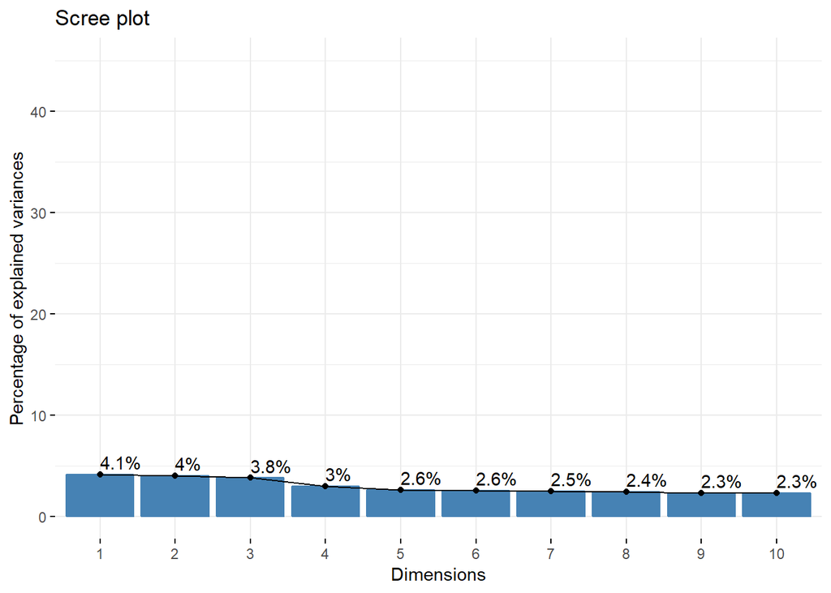

```r
set.seed(123)
n <- round(0.5*nrow(numeric_train_Data))
sample_index <- sample(1:nrow(numeric_train_Data), n)
cat_Data <- Data[sample_index,c(4:6)]
res.mca <- MCA(cat_Data, graph = FALSE)
eig.val <- get_eigenvalue(res.mca)
fviz_screeplot(res.mca, addlabels = TRUE, ylim = c(0, 45))
```

As we can see in the plot, unlike PCA components, these corespondances are not explaining high variance. The first component can only explain 4% of the variance! This tells us that there is not much correlation between the categorical variables and therfore we cannot extract much information through some MCA corespondances. We can try other combinations of categorical variables and see if we can get a satesfactory result.

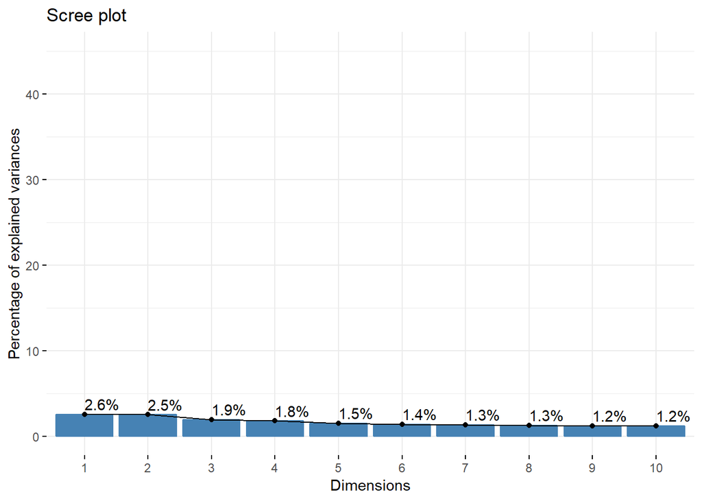

```r
set.seed(123)
cat_Data <- cbind(cat_Data, Data[sample_index,c(18, 19:44)])
res.mca <- MCA(cat_Data, graph = FALSE)
eig.val <- get_eigenvalue(res.mca)
fviz_screeplot(res.mca, addlabels = TRUE, ylim = c(0, 45))
```

Again very low variance. I tried many different combinations of categorical data, MCA doesnt work well with any of them. Therefore I am not going to use it.

# References:

http://www.cioslab.vcu.edu/

http://www.sthda.com/english/articles/26-clustering-basics/86-clustering-distance-measures-essentials/

http://www.sthda.com/english/web/5-bookadvisor/17-practical-guide-to-cluster-analysis-in-r/

http://www.sthda.com/english/articles/29-cluster-validation-essentials/96-determining-the-optimal-number-of-clusters-3-must-know-methods/

http://www.sthda.com/english/wiki/print.php?id=239

http://www.sthda.com/english/articles/25-cluster-analysis-in-r-practical-guide/111-types-of-clustering-methods-overview-and-quick-start-r-code/